# Survival Analysis

- Survival Analysis
- CODE
  - Kaplan-Meier fitter
  - Kaplan-Meier fitter Based on Different Groups
  - Nelson-Aalen fitter Theory
  - Log-Rank-Test
  - Cox-Regression
  - AIC and model selection for parametric models

Library: https://pypi.org/project/lifelines/

Document: https://lifelines.readthedocs.io/en/latest/index.html

Dataset: http://www-eio.upc.edu/~pau/cms/rdata/datasets.html

## Survival Analysis

- Staticial approaches to determine the time an event of interest to occurs. The event of interest could be death, recover, birth, retirement, etc.

### What Analysis

- To find number of days until patients showed symptoms.
- To compare number of day of event of interest amoung various groups.
- To find which treatment has the highest survival probability.
- To find the median number of survial for patients.
- To compare which factor has more impact on patients's survival.

### Use case

Medical

- Cancer patinents survial time analysis
- Medical treatment time analysis

Operation

- Machine failure time analysis
- Operation production failure analysis
- Machine critical level
- Repair period analysis

Business

- Warranty claim period analysis
- Lead to sales time analysis
- Hire to salesperson hires to first sale analysis
- Hire to termination or quit time analysis

Other

- Event history analysis

## Concept

Survival time refers to as an amount of time until when a subject is alive or actively participates in a sutdy period.

### Main types of events:

1. Relapse (relapse-free survival): The length of time after treatment and get well.
2. Progression (progression-free survival): The length of time after treatment and still lives with disease but not get worse.
3. Death: Destruction or permanent end of study.

Censoring is a form of missing data problem in which time to event is not observed for reasons.

Survival and hazard functions

1. Survival Function(S): The probability that an subject survives from the time origin (diagnosis of a disease) to a specified future time t. For example, S(100)=0.8 means that after 100 days, a subject’s survival probability is 0.8.
2. Hazard Function (H): The probability that an subject who is under observation at a time t has an event (death) at that time. For example, If h(100) = 0.8 means that after 100 days, the probability of being dead is 0.8.

# CODE

```python
!pip install lifelines
```

```python
import numpy as np
import pandas as pd
import matplotlib.pyplot as plt
import urllib
from urllib import request
import lifelines
from lifelines import KaplanMeierFitter

print('lifelines version: ', lifelines.__version__)
```

```
lifelines version:  0.25.5
```

```python
# Download data

csv_src = "http://www-eio.upc.edu/~pau/cms/rdata/csv/survival/lung.csv"
csv_path = 'lung.csv'
urllib.request.urlretrieve(csv_src, csv_path)
```

```
('lung.csv', <http.client.HTTPMessage at 0x7f26d1459160>)
```

```python
#  Create dataframe

df = pd.read_csv(csv_path)

#  Precessing
df.loc[df.status == 1, 'dead'] = 0
df.loc[df.status == 2, 'dead'] = 1
df = df.drop(['Unnamed: 0', 'status'], axis=1)

df.head()
```

|  | inst | time | age | sex | ph.ecog | ph.karno | pat.karno | meal.cal | wt.loss | dead |
| --- | --- | --- | --- | --- | --- | --- | --- | --- | --- | --- |
| 0 | 3.0 | 306 | 74 | 1 | 1.0 | 90.0 | 100.0 | 1175.0 | NaN | 1.0 |
| 1 | 3.0 | 455 | 68 | 1 | 0.0 | 90.0 | 90.0 | 1225.0 | 15.0 | 1.0 |
| 2 | 3.0 | 1010 | 56 | 1 | 0.0 | 90.0 | 90.0 | NaN | 15.0 | 0.0 |
| 3 | 5.0 | 210 | 57 | 1 | 1.0 | 90.0 | 60.0 | 1150.0 | 11.0 | 1.0 |
| 4 | 1.0 | 883 | 60 | 1 | 0.0 | 100.0 | 90.0 | NaN | 0.0 | 1.0 |

```python
#  Get statistical info

df.describe()
```

|  | inst | time | age | sex | ph.ecog | ph.karno | pat.karno | meal.cal | wt.loss | dead |
| --- | --- | --- | --- | --- | --- | --- | --- | --- | --- | --- |
| count | 227.000000 | 228.000000 | 228.000000 | 228.000000 | 227.000000 | 227.000000 | 225.000000 | 181.000000 | 214.000000 | 228.000000 |
| mean | 11.088106 | 305.232456 | 62.447368 | 1.394737 | 0.951542 | 81.938326 | 79.955556 | 928.779006 | 9.831776 | 0.723684 |
| std | 8.303491 | 210.645543 | 9.073457 | 0.489870 | 0.717872 | 12.327955 | 14.623177 | 402.174707 | 13.139902 | 0.448159 |
| min | 1.000000 | 5.000000 | 39.000000 | 1.000000 | 0.000000 | 50.000000 | 30.000000 | 96.000000 | -24.000000 | 0.000000 |
| 25% | 3.000000 | 166.750000 | 56.000000 | 1.000000 | 0.000000 | 75.000000 | 70.000000 | 635.000000 | 0.000000 | 0.000000 |
| 50% | 11.000000 | 255.500000 | 63.000000 | 1.000000 | 1.000000 | 80.000000 | 80.000000 | 975.000000 | 7.000000 | 1.000000 |
| 75% | 16.000000 | 396.500000 | 69.000000 | 2.000000 | 1.000000 | 90.000000 | 90.000000 | 1150.000000 | 15.750000 | 1.000000 |
| max | 33.000000 | 1022.000000 | 82.000000 | 2.000000 | 3.000000 | 100.000000 | 100.000000 | 2600.000000 | 68.000000 | 1.000000 |

```python
#  Kaplan-Meier-Fitter
kmf = KaplanMeierFitter()
kmf.fit(durations = df.time, event_observed = df.dead)
```

```
<lifelines.KaplanMeierFitter:"KM_estimate", fitted with 228 total observations, 63 right-censored observations>
```

```python
#  Create event table

#  event_at: Timeline of dataset
#  removed:  The values of subject that are no longer part of our experiment
#  observed: The value of the number of subjects that died during the experiment
#  censored: The number of subject does not have an event during the observation time
#  entrance: The value of new subject in a given timeline
#  at_risk:  The number of current subject under observation

kmf.event_table
```

| event_at | removed | observed | censored | entrance | at_risk |
| --- | --- | --- | --- | --- | --- |
| 0.0 | 0 | 0 | 0 | 228 | 228 |
| 5.0 | 1 | 1 | 0 | 0 | 228 |
| 11.0 | 3 | 3 | 0 | 0 | 227 |
| 12.0 | 1 | 1 | 0 | 0 | 224 |
| 13.0 | 2 | 2 | 0 | 0 | 223 |
| ... | ... | ... | ... | ... | ... |
| 840.0 | 1 | 0 | 1 | 0 | 5 |
| 883.0 | 1 | 1 | 0 | 0 | 4 |
| 965.0 | 1 | 0 | 1 | 0 | 3 |
| 1010.0 | 1 | 0 | 1 | 0 | 2 |
| 1022.0 | 1 | 0 | 1 | 0 | 1 |

187 rows × 5 columns

S(t) = (Number of subjects at risk at the start - Number of subjects that died) / Number of subjects at risk at the start

```python
#  Calculate survival probability  for given time

print("Survival probablity for t=0: ", kmf.predict(0))
print("Survival probablity for t=5: ", kmf.predict(5))
print("Survival probablity for t=11: ", kmf.predict(11))
print("Survival probablity for t=840: ", kmf.predict(840))

print(kmf.predict([0,5,11,840]))
```

```
Survival probablity for t=0:  1.0
Survival probablity for t=5:  0.9956140350877193
Survival probablity for t=11:  0.9824561403508766
Survival probablity for t=840:  0.06712742409441387
0      1.000000
5      0.995614
11     0.982456
840    0.067127
Name: KM_estimate, dtype: float64
```

```python
#  Get survial full list
print(kmf.survival_function_)
```

```
          KM_estimate
timeline
0.0          1.000000
5.0          0.995614
11.0         0.982456
12.0         0.978070
13.0         0.969298
...               ...
840.0        0.067127
883.0        0.050346
965.0        0.050346
1010.0       0.050346
1022.0       0.050346

[187 rows x 1 columns]
```

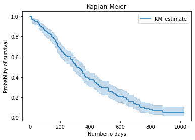

```python
#  Plot the survival graph

kmf.plot()
plt.title("Kaplan-Meier")
plt.xlabel("Number o days")
plt.ylabel("Probablity of survival")
plt.show()
```

```python
#  Get survial time median

survival_time_median = kmf.median_survival_time_
print(" The median survial time: ", survival_time_median)
```

```
 The median survial time:  310.0
```

```python
#  Survival probability wiht confidence interval

survival_confidence_interval = kmf.confidence_interval_survival_function_
survival_confidence_interval
```

|  | KM_estimate_lower_0.95 | KM_estimate_upper_0.95 |
| --- | --- | --- |
| 0.0 | 1.000000 | 1.000000 |
| 5.0 | 0.969277 | 0.999381 |
| 11.0 | 0.953935 | 0.993379 |
| 12.0 | 0.948120 | 0.990813 |
| 13.0 | 0.936682 | 0.985244 |
| ... | ... | ... |
| 840.0 | 0.030728 | 0.123060 |
| 883.0 | 0.017866 | 0.108662 |
| 965.0 | 0.017866 | 0.108662 |
| 1010.0 | 0.017866 | 0.108662 |
| 1022.0 | 0.017866 | 0.108662 |

187 rows × 2 columns

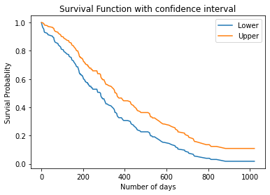

```python
#  Plot survival function with confidence interval

plt.plot(survival_confidence_interval['KM_estimate_lower_0.95'], label="Lower")
plt.plot(survival_confidence_interval['KM_estimate_upper_0.95'], label="Upper")
plt.title("Survival Function with confidence interval")
plt.xlabel("Number of days")
plt.ylabel("Survial Probablity")
plt.legend()
plt.show()
```

```python
#  Cumulative survival
cumu_surv = kmf.cumulative_density_
cumu_surv
```

| timeline | KM_estimate |
| --- | --- |
| 0.0 | 0.000000 |
| 5.0 | 0.004386 |
| 11.0 | 0.017544 |
| 12.0 | 0.021930 |
| 13.0 | 0.030702 |
| ... | ... |
| 840.0 | 0.932873 |
| 883.0 | 0.949654 |
| 965.0 | 0.949654 |
| 1010.0 | 0.949654 |
| 1022.0 | 0.949654 |

187 rows × 1 columns

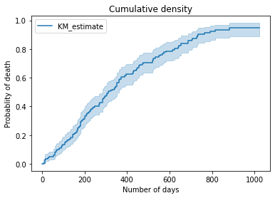

```python
#  Plot cumulative density

kmf.plot_cumulative_density()
plt.title("Cumulative density")
plt.xlabel("Number of days")
plt.ylabel("Probablity of death")
plt.show()
```

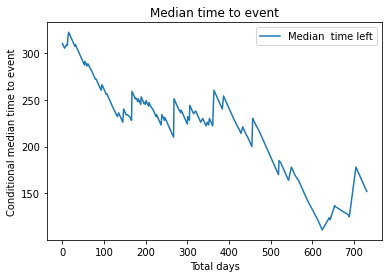

```python
# Median time left for event

median_time_to_event = kmf.conditional_time_to_event_
plt.plot(median_time_to_event, label = "Median  time left")
plt.title("Median time to event")
plt.xlabel("Total days")
plt.ylabel("Conditional median time to event")
plt.legend()
plt.show()
```

### Kaplan-Meier Estimator with groups

```python
# KM for Male and Female

kmf_m = KaplanMeierFitter()
kmf_f = KaplanMeierFitter()

Male = df.query("sex == 1")
Female = df.query("sex == 2")

kmf_m.fit(durations=Male.time, event_observed=Male.dead, label="Male")
kmf_f.fit(durations=Female.time, event_observed=Female.dead, label="Female")
```

```
<lifelines.KaplanMeierFitter:"Female", fitted with 90 total observations, 37 right-censored observations>
```

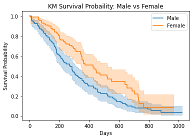

```python
# Plot survival function

kmf_m.plot()
kmf_f.plot()
plt.title("KM Survival Probaility: Male vs Female")
plt.xlabel("Days")
plt.ylabel("Survival Probability")
plt.show()
```

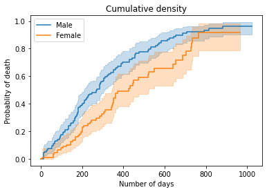

```python
#  Plot cumulative density

kmf_m.plot_cumulative_density()
kmf_f.plot_cumulative_density()
plt.title("Cumulative density")
plt.xlabel("Number of days")
plt.ylabel("Probablity of death")
plt.show()
```

### Hazard function: Nelson-Aalen

```python
from lifelines import NelsonAalenFitter
```

```python
naf = NelsonAalenFitter()

naf.fit(durations = df.time, event_observed = df.dead)
```

```
<lifelines.NelsonAalenFitter:"NA_estimate", fitted with 228 total observations, 63 right-censored observations>
```

H(t) = Number of subjects that died / Number of subjects at risk

```python
#  Cumulative hazard

naf.cumulative_hazard_
```

| timeline | NA_estimate |
| --- | --- |
| 0.0 | 0.000000 |
| 5.0 | 0.004386 |
| 11.0 | 0.017660 |
| 12.0 | 0.022125 |
| 13.0 | 0.031114 |
| ... | ... |
| 840.0 | 2.641565 |
| 883.0 | 2.891565 |
| 965.0 | 2.891565 |
| 1010.0 | 2.891565 |
| 1022.0 | 2.891565 |

187 rows × 1 columns

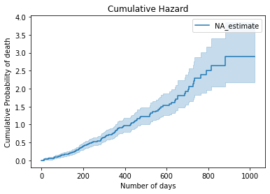

```python
#  Plot cumulative hazard

naf.plot_cumulative_hazard()
plt.title("Cumulative Hazard")
plt.xlabel("Number of days")
plt.ylabel("Cumulative Probability of death")
plt.show()
```

```python
#  Predict

print("t = 500 days: ", naf.predict(500))
```

```
t = 500 days:  1.219546171331098
```

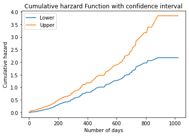

```python
#  cumulative hazard with confidence interval

hazard_confidence_interval = naf.confidence_interval_

plt.plot(hazard_confidence_interval['NA_estimate_lower_0.95'], label="Lower")
plt.plot(hazard_confidence_interval['NA_estimate_upper_0.95'], label="Upper")
plt.title("Cumulative harzard Function with confidence interval")
plt.xlabel("Number of days")
plt.ylabel("Cumulative hazard")
plt.legend()
plt.show()
```

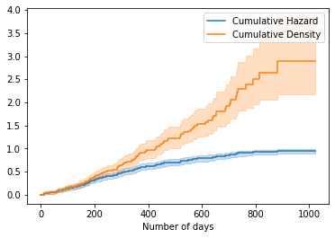

```python
#  Cumulative hazard vs cumulative density

kmf.plot_cumulative_density(label="Cumulative Hazard")
naf.plot_cumulative_hazard(label="Cumulative Density")
plt.xlabel("Number of days")
plt.show()
```

Male vs Female

```python
naf_m = NelsonAalenFitter()
naf_f = NelsonAalenFitter()

naf_m.fit(durations = Male.time, event_observed = Male.dead)
naf_f.fit(durations = Female.time, event_observed = Female.dead)
```

```
<lifelines.NelsonAalenFitter:"NA_estimate", fitted with 90 total observations, 37 right-censored observations>
```

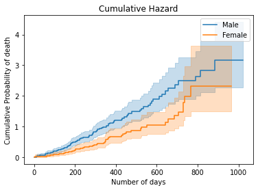

```python
#  Plot cumulative hazard Male vs Female

naf_m.plot_cumulative_hazard(label="Male")
naf_f.plot_cumulative_hazard(label="Female")
plt.title("Cumulative Hazard")
plt.xlabel("Number of days")
plt.ylabel("Cumulative Probability of death")
plt.show()
```

## Log-rank test

Log-rank test is a hypothesis test survival distribution of two samples.

A p-value between 0 and 1 denotes the statistical significance. The smaller the p-value, the more significant the statistical difference between groups being studied is.

Less than (5% = 0.05) P-value means there is a significant difference between the groups we compared.

```python
from lifelines.statistics import logrank_test

time_m = Male.time
event_m = Male.dead

time_f = Female.time
event_f = Female.dead

results = logrank_test(time_m, time_f, event_m, event_f)
results.print_summary()
print("P-value: ", results.p_value)
```

| t_0 | -1 |
| --- | --- |
| null_distribution | chi squared |
| degrees_of_freedom | 1 |
| test_name | logrank_test |

|  | test_statistic | p | -log2(p) |
| --- | --- | --- | --- |
| 0 | 10.33 | <0.005 | 9.57 |

```
P-value:  0.001311164520355457
```

survival function for both groups is significantly different.

## Cox-proportional hazard model

The cox-proportional hazard model is a regression model generally used by medical researchers to determine the relationship between the survival time of a subject and one or more predictor variables.

h(t) = h0(t) * exp(b1X1 + b2X2 + ... + bnXn)

Where,

t = survivaltime

h(t) = hazard function

X1, X2, ..., Xn = covariates

b1, b2, ..., bn = measures the impact of covariates

```python
from lifelines import CoxPHFitter

df2 = pd.read_csv("lung.csv")
df2 = df2.drop(['Unnamed: 0'], axis=1)
df2 = df2.dropna(subset=['inst', 'time', 'status', 'age', 'sex', 'ph.ecog', 'ph.karno', 'pat.karno', 'meal.cal', 'wt.loss'])
df2.loc[df2.status == 1, 'dead'] = 0
df2.loc[df2.status == 2, 'dead'] = 1
df2 = df2.drop(['status'], axis=1)

df2.head()
```

|  | inst | time | age | sex | ph.ecog | ph.karno | pat.karno | meal.cal | wt.loss | dead |
| --- | --- | --- | --- | --- | --- | --- | --- | --- | --- | --- |
| 1 | 3.0 | 455 | 68 | 1 | 0.0 | 90.0 | 90.0 | 1225.0 | 15.0 | 1.0 |
| 3 | 5.0 | 210 | 57 | 1 | 1.0 | 90.0 | 60.0 | 1150.0 | 11.0 | 1.0 |
| 5 | 12.0 | 1022 | 74 | 1 | 1.0 | 50.0 | 80.0 | 513.0 | 0.0 | 0.0 |
| 6 | 7.0 | 310 | 68 | 2 | 2.0 | 70.0 | 60.0 | 384.0 | 10.0 | 1.0 |
| 7 | 11.0 | 361 | 71 | 2 | 2.0 | 60.0 | 80.0 | 538.0 | 1.0 | 1.0 |

```python
df2.describe()
```

|  | inst | time | age | sex | ph.ecog | ph.karno | pat.karno | meal.cal | wt.loss | dead |
| --- | --- | --- | --- | --- | --- | --- | --- | --- | --- | --- |
| count | 167.000000 | 167.000000 | 167.000000 | 167.000000 | 167.000000 | 167.000000 | 167.000000 | 167.000000 | 167.000000 | 167.000000 |
| mean | 10.706587 | 309.934132 | 62.568862 | 1.383234 | 0.958084 | 82.035928 | 79.580838 | 929.125749 | 9.718563 | 0.718563 |
| std | 8.167900 | 209.435591 | 9.210706 | 0.487637 | 0.731011 | 12.778885 | 15.104188 | 413.489837 | 13.378587 | 0.451053 |
| min | 1.000000 | 5.000000 | 39.000000 | 1.000000 | 0.000000 | 50.000000 | 30.000000 | 96.000000 | -24.000000 | 0.000000 |
| 25% | 3.000000 | 174.500000 | 57.000000 | 1.000000 | 0.000000 | 70.000000 | 70.000000 | 619.000000 | 0.000000 | 0.000000 |
| 50% | 11.000000 | 268.000000 | 64.000000 | 1.000000 | 1.000000 | 80.000000 | 80.000000 | 975.000000 | 7.000000 | 1.000000 |
| 75% | 15.000000 | 419.500000 | 70.000000 | 2.000000 | 1.000000 | 90.000000 | 90.000000 | 1162.500000 | 15.000000 | 1.000000 |
| max | 32.000000 | 1022.000000 | 82.000000 | 2.000000 | 3.000000 | 100.000000 | 100.000000 | 2600.000000 | 68.000000 | 1.000000 |

```python
cph = CoxPHFitter()
cph.fit(df2, duration_col='time', event_col='dead')
cph.print_summary()
```

| model | lifelines.CoxPHFitter |
| --- | --- |
| duration col | 'time' |
| event col | 'dead' |
| baseline estimation | breslow |
| number of observations | 167 |
| number of events observed | 120 |
| partial log-likelihood | -491.27 |
| time fit was run | 2020-10-11 01:38:38 UTC |

|  | coef | exp(coef) | se(coef) | coef lower 95% | coef upper 95% | exp(coef) lower 95% | exp(coef) upper 95% | z | p | -log2(p) |
| --- | --- | --- | --- | --- | --- | --- | --- | --- | --- | --- |
| inst | -0.03 | 0.97 | 0.01 | -0.06 | -0.00 | 0.95 | 1.00 | -2.31 | 0.02 | 5.60 |
| age | 0.01 | 1.01 | 0.01 | -0.01 | 0.04 | 0.99 | 1.04 | 1.07 | 0.28 | 1.82 |
| sex | -0.57 | 0.57 | 0.20 | -0.96 | -0.17 | 0.38 | 0.84 | -2.81 | <0.005 | 7.68 |
| ph.ecog | 0.91 | 2.48 | 0.24 | 0.44 | 1.38 | 1.55 | 3.96 | 3.80 | <0.005 | 12.77 |
| ph.karno | 0.03 | 1.03 | 0.01 | 0.00 | 0.05 | 1.00 | 1.05 | 2.29 | 0.02 | 5.49 |
| pat.karno | -0.01 | 0.99 | 0.01 | -0.03 | 0.01 | 0.97 | 1.01 | -1.34 | 0.18 | 2.47 |
| meal.cal | 0.00 | 1.00 | 0.00 | -0.00 | 0.00 | 1.00 | 1.00 | 0.01 | 0.99 | 0.01 |
| wt.loss | -0.02 | 0.98 | 0.01 | -0.03 | -0.00 | 0.97 | 1.00 | -2.11 | 0.03 | 4.85 |

| Concordance | 0.65 |
| --- | --- |
| Partial AIC | 998.54 |
| log-likelihood ratio test | 33.70 on 8 df |
| -log2(p) of ll-ratio test | 14.41 |

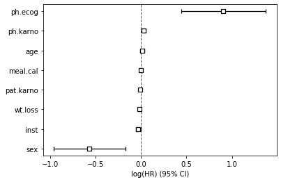

```python
#  All covariates forest plot

cph.plot()
plt.show()
```

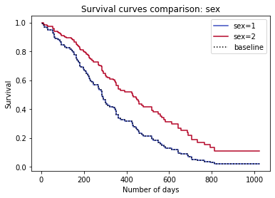

```python
#  Plotting the effect of varying a covariate

cph.plot_partial_effects_on_outcome(covariates='sex', values=[1, 2], cmap='coolwarm')
plt.title("Survival curves comparison: sex")
plt.xlabel("Number of days")
plt.ylabel("Survival")
plt.legend()
plt.show()
```

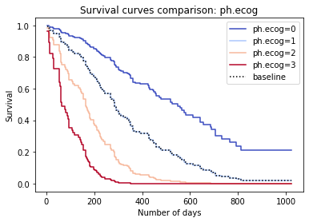

```python
#  Plotting the effect of varying a covariate

cph.plot_partial_effects_on_outcome(covariates='ph.ecog', values=[0, 1, 2, 3], cmap='coolwarm')
plt.title("Survival curves comparison: ph.ecog")
plt.xlabel("Number of days")
plt.ylabel("Survival")
plt.legend()
plt.show()
```

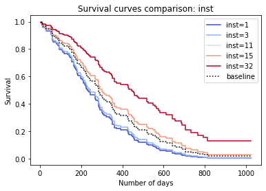

```python
#  Plotting the effect of varying a covariate

cph.plot_partial_effects_on_outcome(covariates='inst', values=[1, 3, 11, 15, 32], cmap='coolwarm')
plt.title("Survival curves comparison: inst")
plt.xlabel("Number of days")
plt.ylabel("Survival")
plt.legend()
plt.show()
```

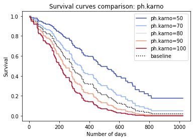

```python
#  Plotting the effect of varying a covariate

cph.plot_partial_effects_on_outcome(covariates='ph.karno', values=[50, 70, 80, 90, 100], cmap='coolwarm')
plt.title("Survival curves comparison: ph.karno")
plt.xlabel("Number of days")
plt.ylabel("Survival")
plt.legend()
plt.show()
```

### AIC and model selection for parametric models

- semi-parametric models (Cox model and Aalen’s model)

Cox Proportional Hazards regression can still fit survival models without knowing (or assuming) the distribution.

- a family of parametric models

a log-normal, or a Weibull, or other parametric distribution make that assumption the maximum likelihood parametric approach

```python
from lifelines import LogLogisticAFTFitter, WeibullAFTFitter, LogNormalAFTFitter

llf = LogLogisticAFTFitter().fit(df2, 'time', 'dead')
lnf = LogNormalAFTFitter().fit(df2, 'time', 'dead')
wf = WeibullAFTFitter().fit(df2, 'time', 'dead')

print(llf.AIC_)
print(lnf.AIC_)
print(wf.AIC_)
```

```
1681.6308575665694
1694.8367594080894
1668.3198611758
```